# Portfolio 4

Lindley Slipetz

2/26/2021

This is my portfolio piece dedicated to Joey. I figure, what’s more romantic than writing a code for someone? To do this project, I asked him to give me any question he’s interested in. He settled on “who’s the best rapper?”. For this project I will be using two datasets. The first dataset tells me the diversity of vocabularies for each rapper. The second dataset gives me information about about the popularity of hip hop artists. I’ll be looking at lyrical complexity and popularity as indicators of being the best rapper (which is probably wrong, but I don’t really know if there even is a quantitative method to determine the best rapper).

Let’s load a package!

```r
library(tidyverse)
```

Let’s load the data!

```r
#popularity <- read.csv("data//music.csv", header = TRUE, #stringsAsFactors = FALSE)
#lyrics <- read.csv("data//music_vocab.csv", header = TRUE, #stringsAsFactors = FALSE)
```

Hmm…something weird happened to my data after I loaded it (like the data disappeared from the file). I don’t really feel like trying to find it again on google. Since I’ve already made the combined datafile that I need, I’ll just save it and reload it here.

```r
#write.csv(all_data, "G:\\My #Drive\\DataScience\\Portfolio_4\\Portfolio_4\\data\\all_dat#a.csv")
all_data <- read.csv("G:\\My Drive\\DataScience\\Portfolio_4\\Portfolio_4\\data\\all_data.csv", header = TRUE, stringsAsFactors = FALSE )
```

Here’s where I made a big dataset where the values of the artists from lyrics are joined to the popularity dataset.

```r
#popularity <- popularity %>%
  #mutate(artist_lastfm = rapper)
#all_data <- inner_join(lyrics, popularity, by = "rapper")
```

There’s a problem with the popularity dataset: there are multiple artists that have the same name and there’s no way to differentiate them. I’m just going to eliminate the ambiguous artists from the dataset.

```r
all_data <- all_data %>%
  filter(ambiguous_artist == FALSE)
```

There’s also some missing data in the lyrics data. Let’s get rid of that.

```r
all_data <- all_data %>%
  filter(words != "Not enough" & words != "not enough" & nzchar(words) == TRUE)
```

One way we can judge the best rapper is by complexity of lyrics. Let’s look at the words variable. We’ll start by looking at who has the most and the least diverse vocabulary.

```r
all_data %>%
  arrange(desc(words))
```

```
##     X.13  notes recalc   era               rapper         rapper_clean
## 1     20          7324 2000s            Busdriver            Busdriver
## 2      7          7879 2000s           Aesop Rock           Aesop Rock
## 3     64          6424 2000s     Jedi Mind Tricks     Jedi Mind Tricks
## 4    112          5443 2000s         Sage Francis         Sage Francis
## 5      6          5233 2010s       Action Bronson       Action Bronson
## 6     80          5566 1990s           Kool Keith           Kool Keith
## 7     58          5930 2000s   Immortal Technique   Immortal Technique
## 8     63          5738 2000s            Jean Grae            Jean Grae
## 9    132          5413 2010s               Watsky               Watsky
## 10    91 remove   4577 1990s              Mac Dre              Mac Dre
## 11    23          5915 2000s              Canibus              Canibus
## 12    27          5496 2000s      CunninLynguists      CunninLynguists
## 13   111          5781 1990s            The Roots            The Roots
## 14    77          5704 2000s        Killah Priest        Killah Priest
```

[output cut: 953 more lines]

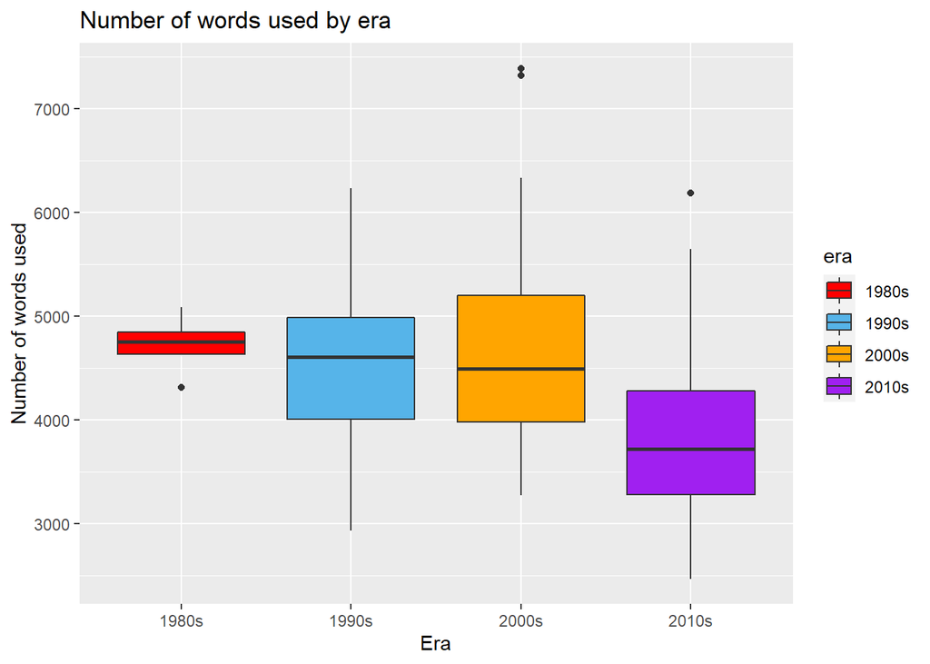

```r
all_data[,'words'] <- gsub(",","",all_data[,'words'])
all_data %>%
   ggplot(aes(x=era, y= as.numeric(words), fill=era)) +
   geom_boxplot() +
  scale_y_continuous("Number of words used", breaks = c(1000, 2000, 3000, 4000, 5000, 6000, 7000, 8000), labels = c("1000", "2000", "3000", "4000", "5000", "6000", "7000", "8000")) +
  scale_x_discrete(name ="Era",
                    limits=c("1980s", "1990s",
                             "2000s", "2010s")) +
  scale_fill_manual(values=c("red", "#56B4E9", "orange", "purple")) +
  labs(title = "Number of words used by era")
```

The minimum number of words is least during the 2010s, and the maximum number of words is greatest during the 2000s. Lil baby is from the 2010s and Busdriver is from the 2000s, so this makes sense. The median from the 1980s to the 2000s stayed pretty constant (between 4500 and 5000), but it plummeted in the 2010s (between 3500 and 4000). The interquartile range is greatest for the 2000s (but seemingly not that much greater than the 1990s and the 2010s), and smallest for the 1980s. I think the main take-away from this graph is that hip hop became much less complex during the 2010s. Let’s look at descriptives to see if that’s supported.

```r
tapply(as.numeric(all_data$words), all_data$era, summary)
```

```
## [[1]]
##    Min. 1st Qu.  Median    Mean 3rd Qu.    Max.
##    3617    3841    4066    4066    4290    4514
##
## $`1980s`
##    Min. 1st Qu.  Median    Mean 3rd Qu.    Max.
##    4313    4636    4756    4728    4848    5090
##
## $`1990s`
##    Min. 1st Qu.  Median    Mean 3rd Qu.    Max.
##    2936    4011    4609    4553    4990    6238
##
## $`1999s`
##    Min. 1st Qu.  Median    Mean 3rd Qu.    Max.
##    4900    4900    4900    4900    4900    4900
##
## $`2000s`
##    Min. 1st Qu.  Median    Mean 3rd Qu.    Max.
##    3275    3982    4494    4744    5204    7392
##
## $`2010s`
##    Min. 1st Qu.  Median    Mean 3rd Qu.    Max.
##    2472    3281    3724    3830    4282    6186
```

As we saw in the graph, the 2010s have the lowest minimum and the 2000s have the highest maximum. The 1980s and the 2000s have similar means. The 2000s have the highest mean and the 2010s have the lowest mean. So, if you’re interested in rappers with complex vocabularies, you should probably listen to something from the 2000s. If you want something simple, then the 2010s is the way to go.

To conclude this section, if having a complex vocabulary is equated with being the best rapper, then Busdriver is the best rapper. He is also from the era of the most complex lyrics, so maybe the 2000s are also the best era for hip hop. Next, we’re going to look at popularity (# of listeners on lastfm) as an indicator of being the best.

We’ll start like before and do a descending list with number of listeners

```r
all_data %>%
  arrange(desc(listeners_lastfm))
```

```
##     X.13  notes recalc   era               rapper         rapper_clean
## 1     38          4480 2000s               Eminem               Eminem
## 2     72          3760 2000s           Kanye West           Kanye West
## 3     36          3347 2010s                Drake                Drake
## 4     62          4275 1990s                Jay-Z                Jay-Z
## 5      4          3384 2000s              50 Cent              50 Cent
## 6    119          3797 1990s           Snoop Dogg           Snoop Dogg
## 7     75          3318 2010s             Kid Cudi             Kid Cudi
## 8    121          4171 2000s                 T.I.                 T.I.
## 9     11          4632 1980s         Beastie Boys         Beastie Boys
## 10   133          3048 2010s          Wiz Khalifa          Wiz Khalifa
## 11     3          3815 1990s                 2Pac                 2Pac
## 12   103      4   3616 2010s          Nicki Minaj          Nicki Minaj
## 13    51          4236 2000s             The Game             The Game
## 14    89          4645 2000s          Lupe Fiasco          Lupe Fiasco
```

[output cut: 953 more lines]

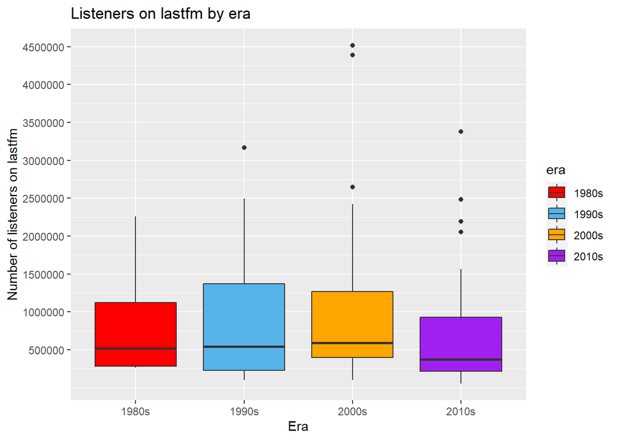

```r
all_data %>%
   ggplot(aes(x=era, y= as.numeric(listeners_lastfm), fill=era)) +
   geom_boxplot() +
  scale_y_continuous("Number of listeners on lastfm", breaks = c(500000, 1000000, 1500000, 2000000, 2500000, 3000000, 3500000, 4000000, 4500000, 5000000), labels = c("500000", "1000000", "1500000", "2000000", "2500000", "3000000", "3500000", "4000000", "4500000", "5000000")) +
  scale_x_discrete(name ="Era",
                    limits=c("1980s", "1990s",
                             "2000s", "2010s")) +
  scale_fill_manual(values=c("red", "#56B4E9", "orange", "purple")) +
  labs(title = "Listeners on lastfm by era")
```

The minimums and the medians for all the graphs look quite similar. The 1990s have a greater interquartile range than the other eras, but I wouldn’t say it’s that much diffrent than the 2000s. The 1980s have the lowest maximum. The 2000s have some outliers that are way above everyon else. Generally, it looks like for all eras, number of listens falls betwwn 250,000 and 1,500,000. Let’s look at the descriptives.

```r
tapply(as.numeric(all_data$listeners_lastfm), all_data$era, summary)
```

```
## [[1]]
##    Min. 1st Qu.  Median    Mean 3rd Qu.    Max.
##  303653  381583  459514  459514  537444  615374
##
## $`1980s`
##    Min. 1st Qu.  Median    Mean 3rd Qu.    Max.
##  266155  282164  517148  890020 1125004 2259629
##
## $`1990s`
##    Min. 1st Qu.  Median    Mean 3rd Qu.    Max.
##  103387  230576  542094  877872 1373552 3169635
##
## $`1999s`
##    Min. 1st Qu.  Median    Mean 3rd Qu.    Max.
##   42505   42505   42505   42505   42505   42505
##
## $`2000s`
##    Min. 1st Qu.  Median    Mean 3rd Qu.    Max.
##  103651  395353  590914  994621 1271505 4517997
##
## $`2010s`
##    Min. 1st Qu.  Median    Mean 3rd Qu.    Max.
##   56067  218572  375769  690136  928843 3379644
```

We’re going to make a scatter plot with number of words on the x-axis and number of listens on the y-axis with an era fill.

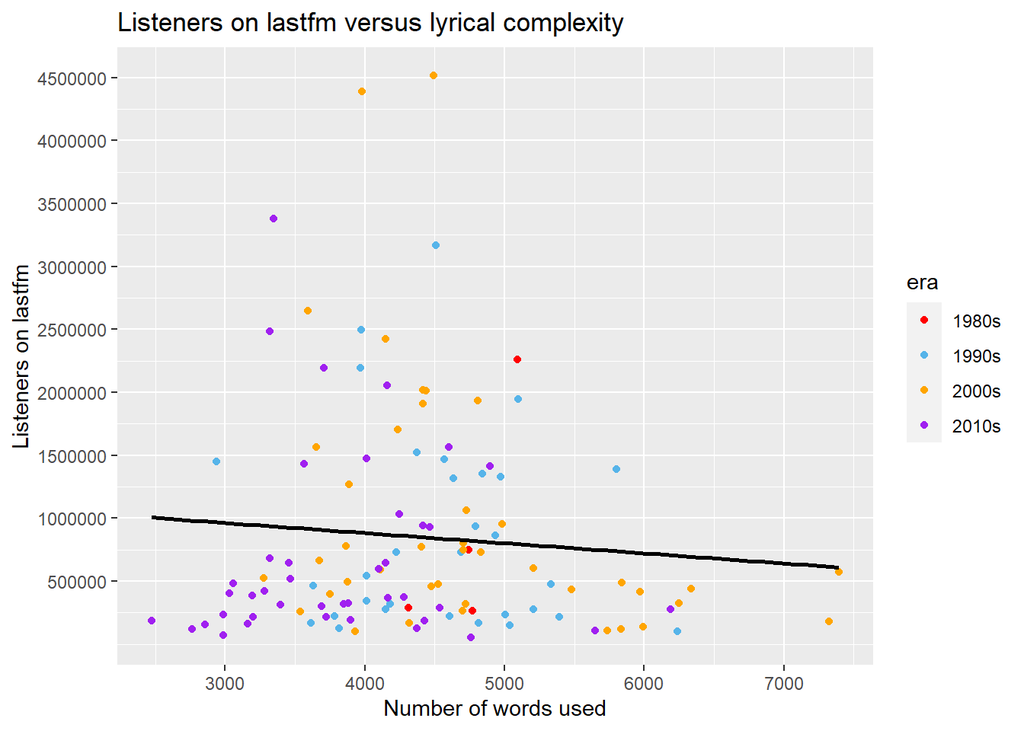

```r
all_data <- all_data %>%
  filter(nzchar(era) == TRUE & era != "1999s")
all_data %>%
   ggplot(aes(x=as.numeric(words), y= listeners_lastfm, color = era)) +
   geom_point() +
  scale_y_continuous("Listeners on lastfm", breaks = c(500000, 1000000, 1500000, 2000000, 2500000, 3000000, 3500000, 4000000, 4500000, 5000000), labels = c("500000", "1000000", "1500000", "2000000", "2500000", "3000000", "3500000", "4000000", "4500000", "5000000")) +
  scale_x_continuous("Number of words used", breaks = c(1000, 2000, 3000, 4000, 5000, 6000, 7000, 8000), labels = c("1000", "2000", "3000", "4000", "5000", "6000", "7000", "8000")) +
  scale_color_manual(values=c("red", "#56B4E9", "orange", "purple")) +
  geom_smooth(method=lm, se=FALSE, aes(group = 1), color="black") +
  labs(title = "Listeners on lastfm versus lyrical complexity")
```

Well, this is a depressing plot: as lyrical complexity increases, popularity decreases. This goes against the hypothesis I had in the previous section that the reason that people listen to 2000s hip hop more is because of lyrical complexity. I think we should look at more graphs to see who the best rapper is. We’ll look at the relationship between popularity and lyrical complexity for the top rappers in popularity and lyrical complexity.

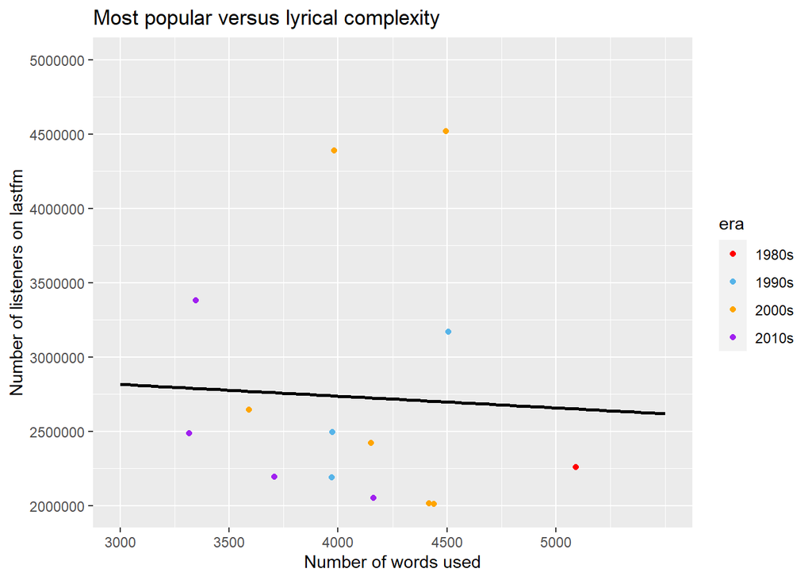

```r
all_data <- all_data %>%
  filter(nzchar(era) == TRUE & era != "1999s")
all_data %>%
   ggplot(aes(x=as.numeric(words), y= as.numeric(listeners_lastfm), color = era)) +
   geom_point() +
  scale_y_continuous("Number of listeners on lastfm", breaks = c(2000000, 2500000, 3000000, 3500000, 4000000, 4500000, 5000000), labels = c( "2000000", "2500000", "3000000", "3500000", "4000000", "4500000", "5000000"), limits= c(2000000, 5000000 )) +
  scale_x_continuous("Number of words used", breaks = c(3000, 3500, 4000, 4500, 5000), labels = c("3000", "3500", "4000", "4500", "5000"), limits=c(3000, 5500)) +
  scale_color_manual(values=c("red", "#56B4E9", "orange", "purple")) +
  geom_smooth(method=lm, se=FALSE, aes(group = 1), color="black", fullrange=TRUE) +
  labs(title = "Most popular versus lyrical complexity")
```

For the top rappers in popularity, again we see a negative relationship between popularity and lyrical complexity. Let’s look at the top artists in lyrics and see the relationship between popularity and lyrical complexity.

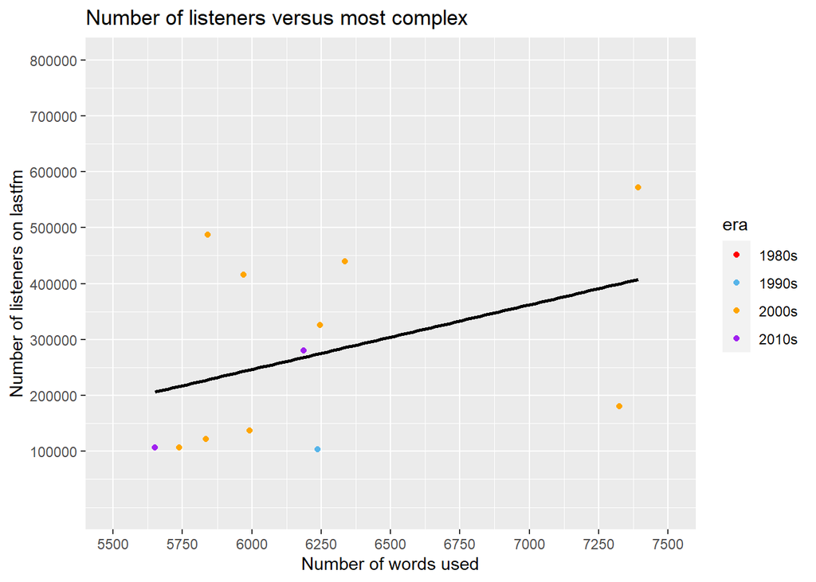

```r
all_data <- all_data %>%
  filter(nzchar(era) == TRUE & era != "1999s")
all_data %>%
   ggplot(aes(x=as.numeric(words), y= as.numeric(listeners_lastfm), color = era)) +
   geom_point() +
  scale_y_continuous("Number of listeners on lastfm", breaks = c(100000, 200000, 300000, 400000, 500000, 600000, 700000, 800000), labels = c("100000", "200000", "300000", "400000", "500000", "600000", "700000", "800000"), limits=c(0,800000)) +
  scale_x_continuous("Number of words used", breaks = c(5500, 5750, 6000, 6250, 6500, 6750, 7000, 7250, 7500), labels = c("5500", "5750", "6000", "6250", "6500", "6750", "7000", "7250", "7500"), limits=c(5500,7500)) +
  scale_color_manual(values=c("red", "#56B4E9", "orange", "purple")) +
  geom_smooth(method=lm, se=FALSE, aes(group = 1), color="black") +
  labs(title = "Number of listeners versus most complex")
```

Finally, some good news! For artists with high lyrical complexity, the higher the lyrical complexity, the greater the popularity.

Okay, what have we learned: Busdriver has the greatest lyrical complexity which puts him in the running for being the best rapper. Alternatively, Eminem is the most popular MC which also puts him in the running for being the best rapper. For most rappers, lyrical complexity is negatively correlated with popularity. This relationship does not hold for the artists with the highest lyrical complexity. Here, lyrical complexity is associated more popularity. If you want to be the best rapper, but you’re not great with words, that’s fine: you can still be super popular. If you want to be the best rapper, and you’re one of the best with words, you’ll also be popular. I’m leaning towards Busdriver as the best rapper because he’s the most popular among the great lyricists.